# Data Mining Assessment 1

Godspower Ogaga Agofure

2024-02-19

## Load required libraries

```r
libraries <- c("tm", "tidytext", "ggplot2", "wordcloud", "syuzhet", "dplyr", "tibble", "textstem", "textdata", "tidyr", "Matrix", "topicmodels", "stringr", "reshape2", "LDAvis", "jsonlite", "kableExtra", "DT","tidyverse","spacyr","quanteda", "igraph" ,"ggraph","plotly") # nolint: line_length_linter.

#install.packages(libraries) # Comment out after first execution # nolint: commented_code_linter.

for (lib in libraries) {
  library(lib, character.only = TRUE) #Library takes function names without quotes, character only must be used in a loop of this kind. # nolint: line_length_linter.
}
```

## Load the dataset

```r
# Load the data and perform data cleaning
file_path <- "Data/Amazon_Book_Reviews.csv"
df <- read.csv(file_path, stringsAsFactors = FALSE, na.strings = c("", "NA"))

# Inspect summary and first few rows of data
print(summary(df))
```

```
##     Title             Book_Price     Reviewer_id            Rating
##  Length:59296       Min.   :  1.00   Length:59296       Min.   :1.000
##  Class :character   1st Qu.: 10.36   Class :character   1st Qu.:4.000
##  Mode  :character   Median : 14.15   Mode  :character   Median :5.000
##                     Mean   : 20.81                      Mean   :4.231
##                     3rd Qu.: 22.99                      3rd Qu.:5.000
##                     Max.   :995.00                      Max.   :5.000
##       Time           Review_title       Review_text        Found_helpful_ratio
##  Min.   :8.688e+08   Length:59296       Length:59296       Min.   :0.0000
##  1st Qu.:1.087e+09   Class :character   Class :character   1st Qu.:0.0000
##  Median :1.169e+09   Mode  :character   Mode  :character   Median :0.6667
##  Mean   :1.173e+09                                         Mean   :0.5491
##  3rd Qu.:1.279e+09                                         3rd Qu.:1.0000
##  Max.   :1.362e+09                                         Max.   :1.0000
##   Publisher         First_author          Genre
##  Length:59296       Length:59296       Length:59296
##  Class :character   Class :character   Class :character
##  Mode  :character   Mode  :character   Mode  :character
##
##
##
```

```r
print(head(df))
```

```
##                                                                          Title
## 1              In Six Days: Why Fifty Scientists Choose to Believe in Creation
## 2                                                                     Lord Jim
## 3                                                             White Socks Only
## 4 The Secret of the Lord: The Simple Key that Will Revive Your Spiritual Power
## 5                   Left to Tell: Discovering God Amidst The Rwandan Holocaust
## 6   Don't Make Me Think: A Common Sense Approach to Web Usability, 2nd Edition
##   Book_Price    Reviewer_id Rating       Time
## 1      10.19  APD7XINUVG5AL      4  999388800
## 2      15.56  AITANZIKX8Y55      5  915580800
## 3       5.16  AYB19RB36GLZL      4 1339718400
## 4      14.99  A1BOLCK0Q50PW      5 1284854400
## 5      17.48  A3WKJ88K7898T      5 1355702400
## 6      20.86 A1E6I4IPWWYTUC      5 1198108800
##                                                Review_title
```

[output cut: 27 more lines]

```r
print(colSums(is.na(df)))
```

```
##               Title          Book_Price         Reviewer_id              Rating
##                   0                   0                   0                   0
##                Time        Review_title         Review_text Found_helpful_ratio
##                   0                   0                   0                   0
##           Publisher        First_author               Genre
##                   0                   3                   0
```

# Task A – Text Mining

### Data Selection and Sampling

```r
set.seed(112232)

selected_columns <- c("Title","Book_Price","Reviewer_id","Found_helpful_ratio", "Rating","Time", "Review_title","Review_text","Publisher", "First_author", "Genre")

df <- df[, selected_columns] #Save the selected columns into df

df <- na.omit(df) # Removes all rows containing null values

df$Review_no <- 1:nrow(df) # Adds identifier column to reviews
```

```r
genre_counts <- count(df,Genre, sort=TRUE) # Count number of reviews by Genre and sort
head(genre_counts, n = 10) # Print top 5 most reviewed Genre
```

```
##                        Genre     n
## 1                    Fiction 12663
## 2                   Religion  4266
## 3           Juvenile Fiction  3190
## 4  Biography & Autobiography  3094
## 5                    History  3018
## 6       Business & Economics  2930
## 7                  Computers  2220
## 8     Family & Relationships  1788
## 9                    Cooking  1705
## 10          Health & Fitness  1670
```

```r
summary(genre_counts) # Print summary statistics to see min. max. and average no. of reviews
```

```
##     Genre                 n
##  Length:85          Min.   :    1.0
##  Class :character   1st Qu.:    8.0
##  Mode  :character   Median :  225.0
##                     Mean   :  697.6
##                     3rd Qu.:  741.0
##                     Max.   :12663.0
```

```r
set.seed(1112) # Set random seed for repeatability

# Sample, for example, 1000 rows
sampled_index <- sample(nrow(df),1000)
sampled_df <- df[sampled_index,]

print(summary(sampled_df))
```

```
##     Title             Book_Price     Reviewer_id        Found_helpful_ratio
##  Length:1000        Min.   :  1.00   Length:1000        Min.   :0.0000
##  Class :character   1st Qu.: 10.17   Class :character   1st Qu.:0.0000
##  Mode  :character   Median : 13.82   Mode  :character   Median :0.6364
##                     Mean   : 19.88                      Mean   :0.5307
##                     3rd Qu.: 22.00                      3rd Qu.:1.0000
##                     Max.   :287.38                      Max.   :1.0000
##      Rating         Time           Review_title       Review_text
##  Min.   :1.0   Min.   :8.756e+08   Length:1000        Length:1000
##  1st Qu.:4.0   1st Qu.:1.090e+09   Class :character   Class :character
##  Median :5.0   Median :1.173e+09   Mode  :character   Mode  :character
##  Mean   :4.2   Mean   :1.175e+09
##  3rd Qu.:5.0   3rd Qu.:1.282e+09
##  Max.   :5.0   Max.   :1.362e+09
##   Publisher         First_author          Genre             Review_no
##  Length:1000        Length:1000        Length:1000        Min.   :   21
##  Class :character   Class :character   Class :character   1st Qu.:15192
##  Mode  :character   Mode  :character   Mode  :character   Median :29548
##                                                           Mean   :29756
##                                                           3rd Qu.:45477
##                                                           Max.   :59271
```

```r
head(sampled_df)
```

```
##                                                                                                     Title
## 34433                                             Heir to the Shadows (The Black Jewels Trilogy, Book II)
## 33660 Liberal Fascism: The Secret History of the American Left, From Mussolini to the Politics of Meaning
## 36493                                                   Van Johnson: MGM's Golden Boy (Hollywood Legends)
## 37882                                  Reformed Is Not Enough: Recovering the Objectivity of the Covenant
## 12326                          Collaborative Web Development: Strategies and Best Practices for Web Teams
## 37156                                         Twenty Things Adopted Kids Wish Their Adoptive Parents Knew
##       Book_Price    Reviewer_id Found_helpful_ratio Rating       Time
## 34433       7.56 A39AYO0482HKKI           0.3000000      2  960768000
## 33660      18.97 A3RQZJATH3FNX2           0.5000000      5 1206403200
## 36493      21.90 A10SJZ58N9J2WS           0.2857143      4 1290470400
## 37882      17.00  AQ6WF69GZ2FQ2           0.0000000      5 1341360000
## 12326      41.46  A588IU173L2B0           1.0000000      5  938390400
## 37156      10.20  A82J23OXJJS5G           0.6562500      5 1133740800
##                                                       Review_title
```

[output cut: 27 more lines]

**Now that our data is sampled, we can begin to perform some analysis on the reviews. We will begin by tokenizing our data**

```r
word_tokenized_data <- sampled_df %>%
  unnest_tokens(output = word, input = "Review_text", token = "words", to_lower = TRUE) # Tokenize review_text column by word

bigram_tokenized_data <- df %>%
  unnest_tokens(output = bigram, input = "Review_text", token = "ngrams", n=2, to_lower = TRUE) # Tokenize review column to bigrams
```

**We can perform some initial exploratory analysis to see the most common words and bigrams in our reviews.**

### Plot of top 10 words

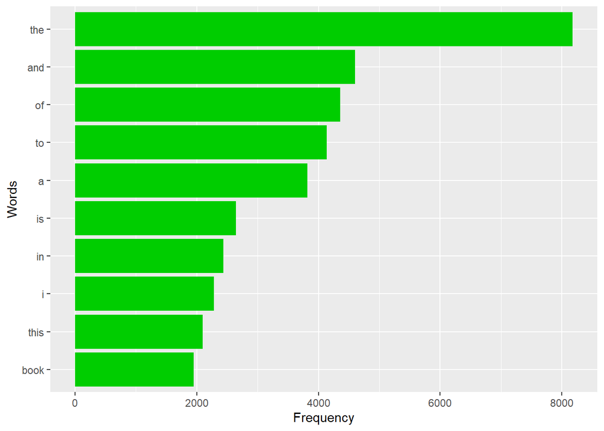

```r
word_counts <- word_tokenized_data %>%
  count(word, sort = TRUE) # Counts the occurences of each word and sorts.

ggplot(word_counts[1:10, ], aes(x = reorder(word, n), y = n)) + # Plots first 10 rows of word counts, with word (ordered by n) on the x axis and n on the y axis
  geom_col(fill = "green3") + # Sets colours of bars to blue
  labs(x = "Words", y = "Frequency") + # Defines x and y labels
  coord_flip() # Flips coordinates so words go on the y axis (for readability)
```

### Initial Word Cloud

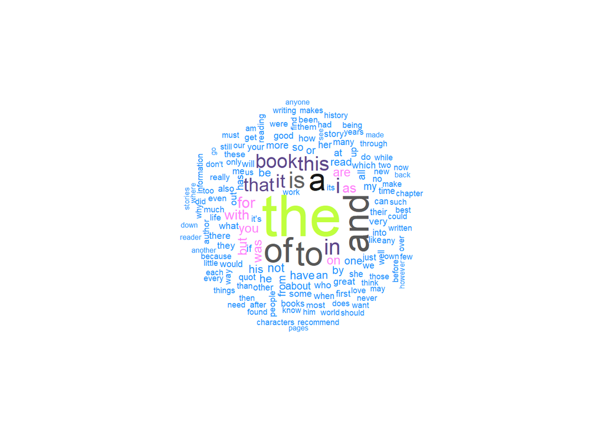

```r
set.seed(1)
wordcloud(words = word_counts$word, freq = word_counts$n, min.freq = 100, random.order=FALSE, random.color=FALSE, colors = sample(colors(), size = 10))
```

```r
# words = vector of words, freq = vector of frequencies, min.freq = minimum frequency to plot, random.order=FALSE means words are plotted in order of n, random.color=FALSE colors according to frequency and colors key word specifies colors to use.
```

### Plot of top 10 bigrams

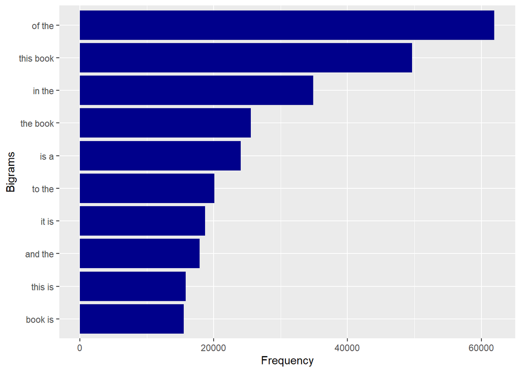

```r
# Count the frequency of each bigram in the tokenized data
bigram_counts <- bigram_tokenized_data %>%
  count(bigram, sort = TRUE)

# Create a bar plot of the top 10 most frequent bigrams
ggplot(bigram_counts[1:10, ], aes(x = reorder(bigram, n), y = n)) +
  geom_col(fill = "blue4") +
  labs(x = "Bigrams", y = "Frequency") +
  coord_flip()
```

### Cleaning Data

Initial analysis revealed that a lot of filler or “stop” words are present and dominating the visualizations. To address this issue, we will perform cleaning that includes the following steps:

- Removes stop words
- Removes special characters and numbers
- Lemmatizes words
- Removes empty tokens

```r
clean_tokens <- word_tokenized_data %>%
  anti_join(stop_words, by = "word") # Removes stop words

clean_tokens$word <- gsub("[^a-zA-Z ]", "", clean_tokens$word) %>% # Remove special characters and numbers
  na_if("") %>% # Replaces empty strings with NA
  lemmatize_words() # Lemmatizes text

clean_tokens <- na.omit(clean_tokens) # Removes null values

#Untokenized and then retokenized to get cleaned bigrams
untokenized_data <- clean_tokens %>%
  group_by(Review_no) %>%
  summarize(clean_review = paste(word, collapse = " ")) %>% # for each review number, takes every word and joins them with spaces
  inner_join(df, by="Review_no") # Joins cleaned reviews to original df

clean_bigrams <- untokenized_data %>%
  unnest_tokens(output = bigram, input = "clean_review", token = "ngrams", n=2, to_lower = TRUE) # Tokenize word column to bigrams
```

### Top 10 Words and Bigrams After Cleaning

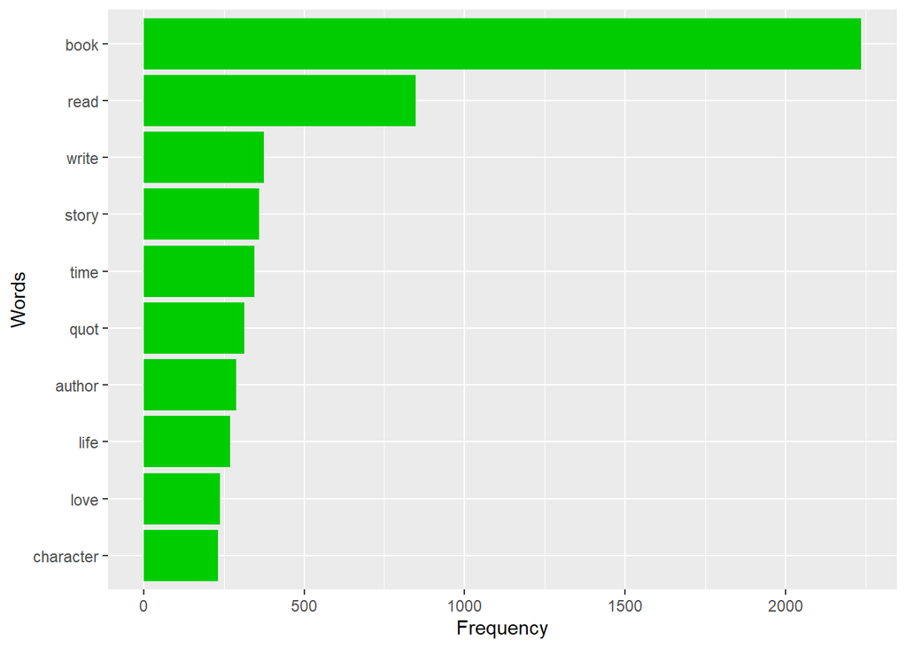

```r
# Count the frequency of each word in the cleaned tokens
word_counts <- clean_tokens %>%
  count(word, sort = TRUE)

# Select the top 10 words based on frequency
top_words <- top_n(word_counts, 10, n)$word

# Filter the word counts to include only the top N words
filtered_word_counts <- filter(word_counts, word %in% top_words)

# Reorder the filtered word counts based on frequency
filtered_word_counts$word <- factor(filtered_word_counts$word, levels = top_words[length(top_words):1])

# Create a bar plot of the top N words and their frequencies
ggplot(filtered_word_counts, aes(x = reorder(word, n), y = n)) +
  geom_col(fill = "green3") +  # Set bar fill color
  labs(x = "Words", y = "Frequency") +  # Set axis labels
  coord_flip()  # Flip the coordinates for horizontal orientation
```

### Word Cloud After Cleaning

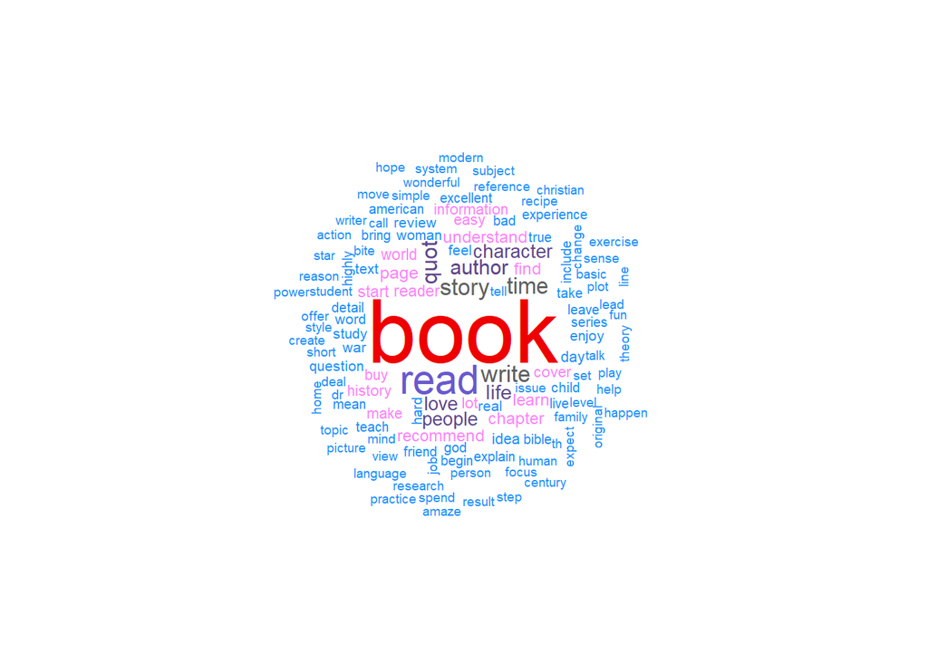

```r
set.seed(1)
wordcloud(words = word_counts$word, freq = word_counts$n, min.freq = 50, random.order=FALSE, random.color=FALSE, colors = sample(colors(), size = 20))
```

**Observation**

> Book is the most common word in the reiew text

### Top 10 Genre by Rating

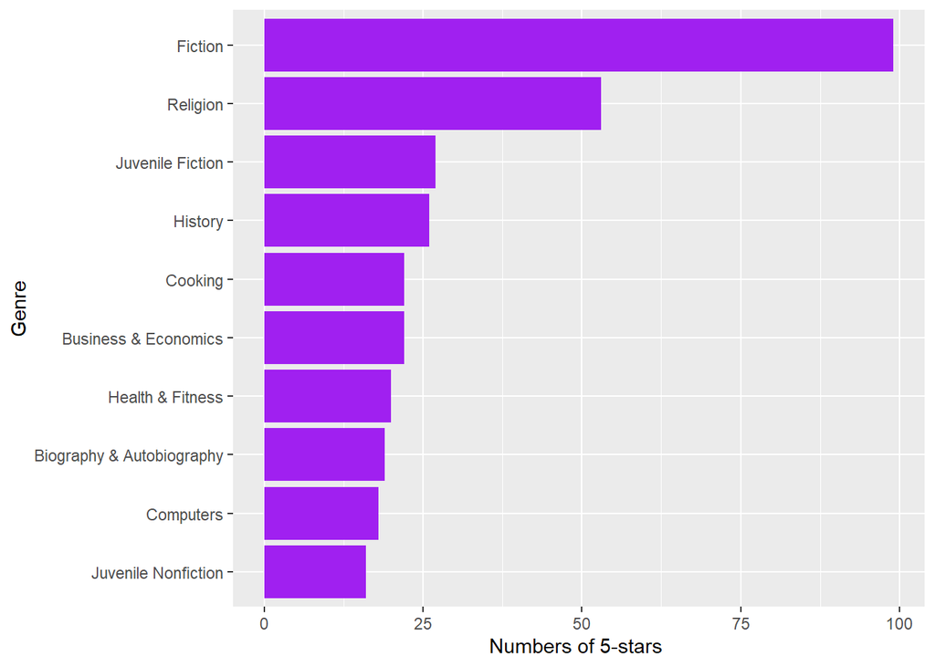

```r
# Sample, remove duplicates, and handle null values
set.seed(1112) # Set random seed for repeatability

# Sample, for example, 500 rows
sampled_index <- sample(nrow(df), 1000)
sampled_df <- df[sampled_index, ]

# Remove duplicates based on Book_Title
sampled_df <- sampled_df[!duplicated(sampled_df$Title), ]

# Remove rows with null values
sampled_df <- na.omit(sampled_df)

# Filter the dataset for 5-star ratings
five_star_books <- sampled_df[sampled_df$Rating == 5, ]

# Group by genre and count the number of books in each genre
genre_counts <- five_star_books %>%
  group_by(Genre) %>%
  summarize(Count = n())

# Order genres by count and select the top N genres
top_genres <- genre_counts %>%
  arrange(desc(Count)) %>%
  head(10)  # Change 10 to the desired number of top genres

# Visualize the top genres with a vertical bar chart
ggplot(top_genres, aes(x = reorder(Genre, Count), y = Count)) +
  geom_bar(stat = "identity", fill = "purple") +
  labs(x = "Genre", y = "Numbers of 5-stars ") +
  coord_flip()  # Flip coordinates for vertical bars
```

**Observation**

> Fiction has the higest numbers of 5-star rating.

```r
set.seed(1112)

# Find the indices of the top 10 books with the maximum values in the "Time" column
top_time_indices <- head(order(-sampled_df$Time), 10)

# Create a dataframe with information about the top 10 books (excluding null values)
top_books_df <- data.frame(
  Review_Title = sampled_df$Review_title[top_time_indices],
  Author = sampled_df$First_author[top_time_indices],
  Reviewer = sampled_df$Reviewer_id[top_time_indices],
  Genre = sampled_df$Genre[top_time_indices],
  Time_in_seconds = sampled_df$Time[top_time_indices]
)

# Exclude rows with null values
top_books_df <- top_books_df[complete.cases(top_books_df), ]

# Render an interactive DataTable
datatable(top_books_df, options = list(pageLength = 10))
```

|  | Review_Title | Author | Reviewer | Genre | Time_in_seconds |
| --- | --- | --- | --- | --- | --- |
| 1 | Indispensable - about to order my second copy since I used the first one to pieces | Beth Hensperger | A15IIKGIUJWPL | Cooking | 1362096000 |
| 2 | Wonderful Book | David A. Carter | A7TWVBI74WVL9 | Juvenile Fiction | 1362096000 |
| 3 | Excellent book on communication | Marshall B. Rosenberg | A2WIA44SATUPDW | Self-Help | 1362009600 |
| 4 | Great | Jean Watanabe Hee | A1XQ0F01CF84Y3 | Cooking | 1361750400 |
| 5 | Start it and keep at it...it is wonderful. | Susan Scarf Merrell | A1TK5MD3X4D5R6 | Fiction | 1361750400 |
| 6 | Worthwhile for reading, challenging, good worldview | Beth Moore | A45H6LRP2OHXU | Religion | 1361404800 |
| 7 | Wonderful purchase,can't wait to do some | Leigh Radford | A2PRL9WBGBW6WC | Crafts &amp; Hobbies | 1361318400 |
| 8 | Great world building and potentially great characters but OK story. | Kresley Cole | ANVL8BXGQ5JFO | Fiction | 1361145600 |
| 9 | Pleasantly surprised | FREDERICK DOUGLASS | AKUYA397YH084 | Biography &amp; Autobiography | 1361145600 |
| 10 | Logical method | Eugene Jackson | A3NDOSZW1BPM95 | Foreign Language Study | 1361145600 |

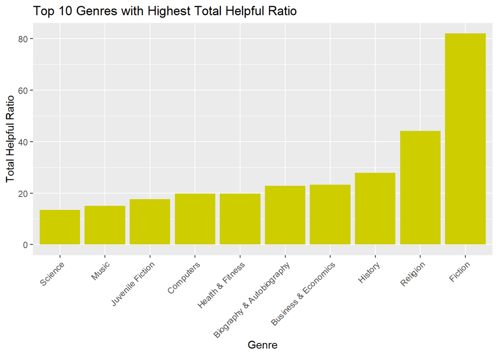

```r
# Set seed for reproducibility
set.seed(1112)

# Aggregate data by genre and calculate the total helpful ratio for each genre
genre_total_helpful_ratio <- aggregate(Found_helpful_ratio ~ Genre, data = sampled_df, FUN = sum)

# Sort the genres based on the total helpful ratio in descending order
sorted_genres <- genre_total_helpful_ratio[order(-genre_total_helpful_ratio$Found_helpful_ratio), ]

# Select the top 10 genres with the highest total helpful ratio
top_10_genres <- head(sorted_genres, 10)

# Create a bar plot
plot <- ggplot(top_10_genres, aes(x = reorder(Genre, Found_helpful_ratio), y = Found_helpful_ratio)) +
  geom_bar(stat = "identity", fill = "yellow3") +
  labs(title = "Top 10 Genres with Highest Total Helpful Ratio",
       x = "Genre",
       y = "Total Helpful Ratio") +
  theme(axis.text.x = element_text(angle = 45, hjust = 1))

# Display the plot
plot
```

**Observation**

> The genre “Fiction” has the highest total found helpful review score. The chart also gives an insight into the top genre with most helpful review ratios.

### The Average Book Price for Each Genre

[figure not shown]

**Observation**

> Computers has the hight average price, followed by Science

# Task B – Sentiment Analysis

### Data Selection and Sampling

```r
df <- read.csv(file_path, stringsAsFactors = FALSE, na.strings = c("", "NA"))

selected_columns <- c("Title", "Rating","Time","Reviewer_id","Review_text","Publisher", "First_author", "Genre" )

df <- df[, selected_columns]

df <- na.omit(df) # Removes all rows containing null values

df$Review_no <- 1:nrow(df)
```

```r
genre_counts <- count(df,Genre, sort=TRUE) # Count number of reviews by genre and sort
head(genre_counts) # Print top 5 most reviewed genre
```

```
##                       Genre     n
## 1                   Fiction 12663
## 2                  Religion  4266
## 3          Juvenile Fiction  3190
## 4 Biography & Autobiography  3094
## 5                   History  3018
## 6      Business & Economics  2930
```

```r
summary(genre_counts)
```

```
##     Genre                 n
##  Length:85          Min.   :    1.0
##  Class :character   1st Qu.:    8.0
##  Mode  :character   Median :  225.0
##                     Mean   :  697.6
##                     3rd Qu.:  741.0
##                     Max.   :12663.0
```

```r
set.seed(1) # Set random seed for repeatability

# Take sample of 5 Genre
sample_index<- sample(length(unique(df$Genre)), 5) #Sample (Size of population, Size of sample), returns index for sample
sampled_genre <- unique(df$Genre)[sample_index] # Take Genre at index defined previously

df <- df %>%
  filter(Genre %in% sampled_genre) # Select only rows where genre is one of sampled_genres

print(summary(df))
```

```
##     Title               Rating          Time           Reviewer_id
##  Length:5122        Min.   :1.00   Min.   :8.711e+08   Length:5122
##  Class :character   1st Qu.:4.00   1st Qu.:1.109e+09   Class :character
##  Mode  :character   Median :5.00   Median :1.196e+09   Mode  :character
##                     Mean   :4.34   Mean   :1.190e+09
##                     3rd Qu.:5.00   3rd Qu.:1.297e+09
##                     Max.   :5.00   Max.   :1.362e+09
##  Review_text         Publisher         First_author          Genre
##  Length:5122        Length:5122        Length:5122        Length:5122
##  Class :character   Class :character   Class :character   Class :character
##  Mode  :character   Mode  :character   Mode  :character   Mode  :character
##
##
##
##    Review_no
##  Min.   :    1
##  1st Qu.:15320
##  Median :30119
##  Mean   :29867
##  3rd Qu.:44759
##  Max.   :59285
```

```r
head(df)
```

```
##                                                                          Title
## 1              In Six Days: Why Fifty Scientists Choose to Believe in Creation
## 2 The Secret of the Lord: The Simple Key that Will Revive Your Spiritual Power
## 3                                    His Princess: Love Letters from Your King
## 4                       The Complete Idiot's Guide to the Bible, Third Edition
## 5                                                                        Arena
## 6           The ACLU vs. America: Exposing the Agenda to Redefine Moral Values
##   Rating       Time    Reviewer_id
## 1      4  999388800  APD7XINUVG5AL
## 2      5 1284854400  A1BOLCK0Q50PW
## 3      5 1207353600  A8N80BRZD173I
## 4      3 1127260800 A3H3MVVD23OJBW
## 5      5 1098489600  AS92IURSLO4YZ
## 6      5 1194480000 A3JKVX4LQ3L2YD
##                                                                                                                                                                                                                                                                                                          …
## 1                                                                                                                                                                                                                                                                                                        …
## 2                                                                                                                                                                                                                                                                                                        …
## 3                                                                                                                                                                                                                                                                                                        …
## 4 The Complete Idiot's Guide to the Bible is one of approximately 30 titles in the "Complete Idiot's" Series on religion.The "Idiot Series" is a publication of the Penguin Group.James S. Bell Jr. is the owner of Whitestone Communications and has served as executive editor of Moody Press and direc…
## 5                                                                                                                                                                                                                                                                                                        …
## 6                                                                                                                                                                                                                                                                                                        …
##                   Publisher        First_author    Genre Review_no
## 1 New Leaf Publishing Group  John F. Ashton PhD Religion         1
## 2              Nelson Books        Dannah Gresh Religion         4
## 3                 Multnomah Sheri Rose Shepherd Religion        15
## 4                   Penguin       James S. Bell Religion        60
## 5      B&H Publishing Group        David Prince Religion        63
## 6                 B&H Books          Alan Sears Religion        88
```

### Tokenize the Reviews

Now that our data is sampled, we can begin to perform some analysis on the reviews. We will begin by tokenizing our data.

```r
word_tokenized_data <- df %>%
  unnest_tokens(output = word, input = "Review_text", token = "words", to_lower = TRUE) # Tokenize review column by word

bigram_tokenized_data <- df %>%
  unnest_tokens(output = bigram, input = "Review_text", token = "ngrams", n=2, to_lower = TRUE) # Tokenize review column to bigrams
```

### Initial Exploratory Analysis

We can perform some initial exploratory analysis to see the most common words and bigrams in our reviews.

### Plot of top 10 words

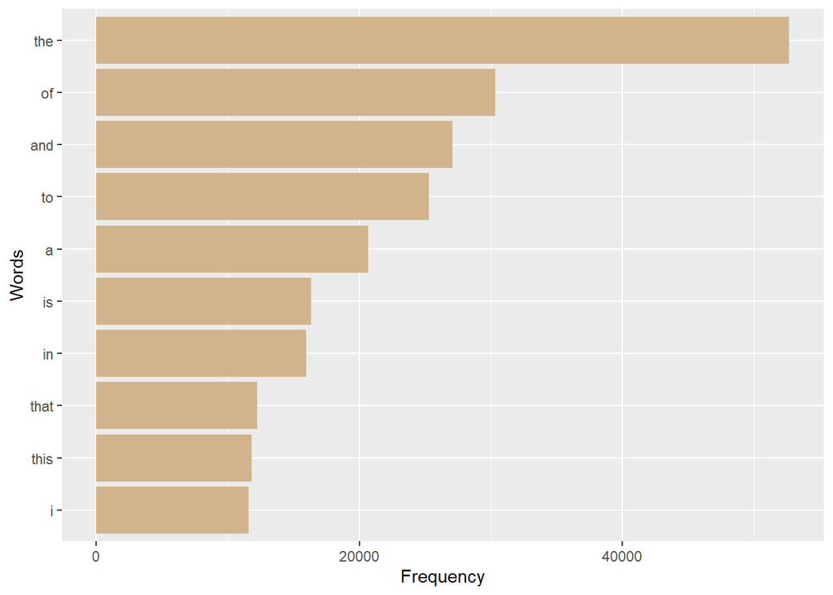

```r
word_counts <- word_tokenized_data %>%
  count(word, sort = TRUE) # Counts the occurences of each word and sorts.

ggplot(word_counts[1:10, ], aes(x = reorder(word, n), y = n)) + # Plots first 10 rows of word counts, with word (ordered by n) on the x axis and n on the y axis
  geom_col(fill = "tan") + # Sets colours of bars to blue
  labs(x = "Words", y = "Frequency") + # Defines x and y labels
  coord_flip() # Flips coordinates so words go on the y axis (for readability)
```

### Word Cloud

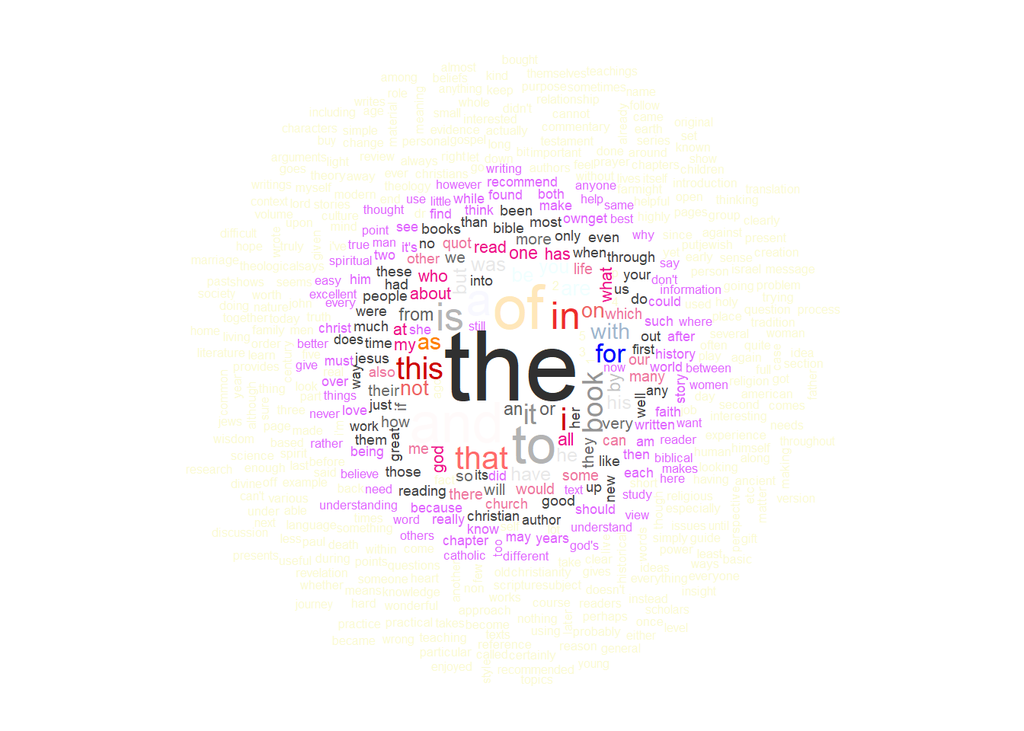

```r
set.seed(123)
wordcloud(words = word_counts$word, freq = word_counts$n, min.freq = 200, random.order=FALSE, random.color=FALSE, colors = sample(colors(), size = 100 ))
```

```r
# words = vector of words, freq = vector of frequencies, min.freq = minimum frequency to plot, random.order=FALSE means words are plotted in order of n, random.color=FALSE colors according to frequency and colors key word specifies colors to use.
```

### Plot of top 10 bigrams

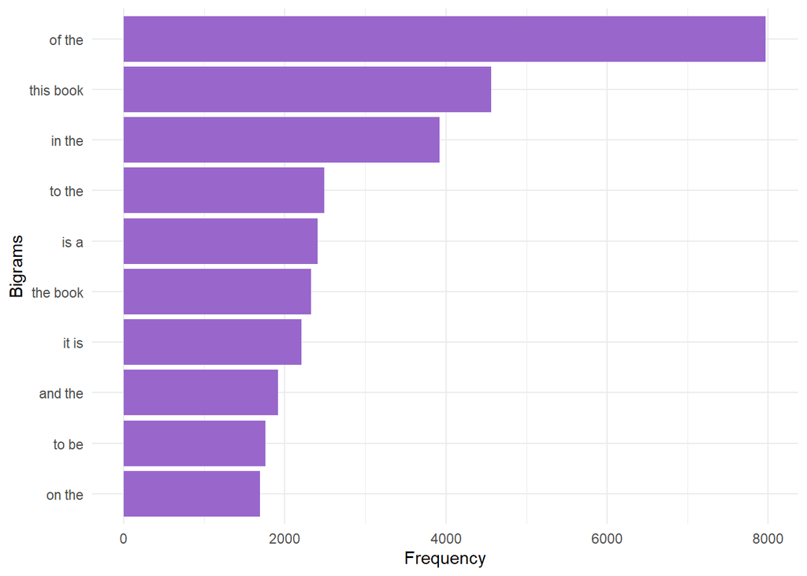

```r
bigram_counts <- bigram_tokenized_data %>%
  count(bigram, sort = TRUE)

ggplot(bigram_counts[1:10, ], aes(x = reorder(bigram, n), y = n)) +
  geom_col(fill = "#9966CC") +
  labs(x = "Bigrams", y = "Frequency") +
  coord_flip() +
  theme_minimal()
```

### Cleaning Data: Getting rid of stop words

Initial analysis revealed that a lot of filler or “stop” words are present and dominating the visualisations we will perform cleaning that does the following: - Removes stop words - Removes special characters and numbers - lemmatizes words - Removes empty tokens

```r
clean_tokens <- word_tokenized_data %>%
  anti_join(stop_words, by = "word") # Removes stop words

clean_tokens$word <- gsub("[^a-zA-Z ]", "", clean_tokens$word) %>% # Remove special characters and numbers
  na_if("") %>% # Replaces empty strings with NA
  lemmatize_words() # Lemmatizes text

clean_tokens <- na.omit(clean_tokens) # Removes null values

# Untokenized and then retokenized to get cleaned bigrams
untokenized_data <- clean_tokens %>%
  group_by(Review_no) %>%
  summarize(clean_review = paste(word, collapse = " ")) %>% # for each review number, takes every word and joins them with spaces
  inner_join(df[,c(1,4,5,6,7,8,9)], by="Review_no") # Joins cleaned reviews to original df

clean_bigrams <- untokenized_data %>%
  unnest_tokens(output = bigram, input = "clean_review", token = "ngrams", n=2, to_lower = TRUE) # Tokenize word column to bigrams
```

### Top 10 Words and Bigrams After Cleaning

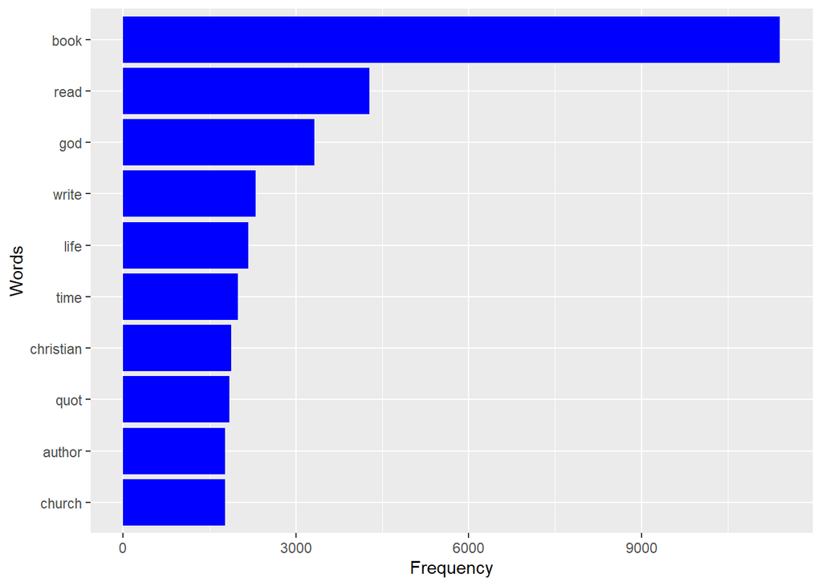

```r
# Count the frequency of each word in the cleaned tokens
word_counts <- clean_tokens %>%
  count(word, sort = TRUE)

# Select the top 10 words based on frequency
top_words <- top_n(word_counts, 10, n)$word

# Filter word counts to include only the top words
filtered_word_counts <- filter(word_counts, word %in% top_words)

# Ensure the order of words in the plot matches their frequency
filtered_word_counts$word <- factor(filtered_word_counts$word, levels = top_words[length(top_words):1])

# Create a bar plot of the top words and their frequencies
ggplot(filtered_word_counts, aes(x = reorder(word, n), y = n)) +
  geom_col(fill = "blue") +  # Set bar fill color
  labs(x = "Words", y = "Frequency") +  # Set axis labels
  coord_flip()   # Flip coordinates for horizontal bar plot
```

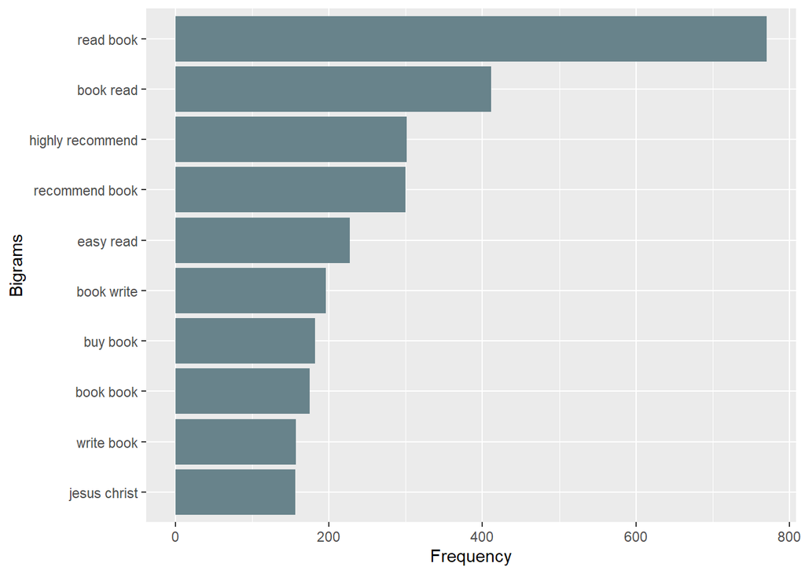

```r
# Calculate the counts of bigrams
bigram_counts <- clean_bigrams %>%
  count(bigram, sort = TRUE)

# Select the top N bigrams based on frequency
top_bigrams <- top_n(bigram_counts, 10, n)$bigram

# Filter the bigram counts to include only the top bigrams
filtered_bigram_counts <- filter(bigram_counts, bigram %in% top_bigrams)

# Reorder the bigrams based on frequency and convert to factor
filtered_bigram_counts$bigram <- factor(filtered_bigram_counts$bigram, levels = top_bigrams[length(top_bigrams):1])

# Create a bar plot of the top bigrams
ggplot(filtered_bigram_counts, aes(x = reorder(bigram, n), y = n)) +
  geom_col(fill = "lightblue4") +
  labs(x = "Bigrams", y = "Frequency") +
  coord_flip()
```

### Top 10 Words & Bigrams grouped by genre

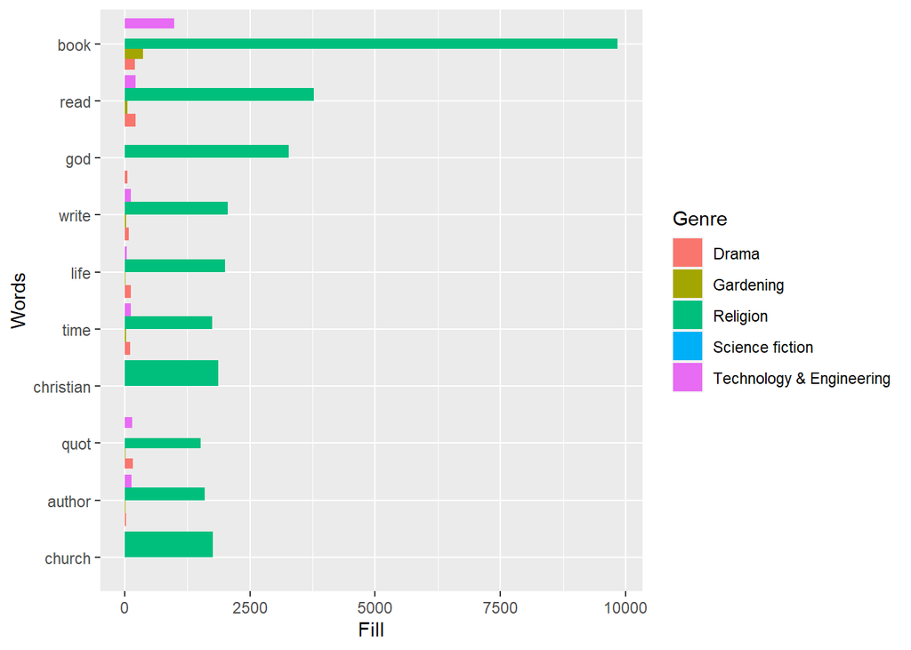

```r
# Grouped Words
top_words <- top_n(word_counts,10,n)$word # Gets a vector of top 10 words

# Groups clean_tokens by Genre and counts the number of occurrences of each word, and filters to only the top 10 words.
grouped_count <- group_by(clean_tokens, Genre) %>%
  count(word) %>%
  filter(word %in% top_words)

grouped_count$word <- factor(grouped_count$word, levels = top_words[length(top_words):1]) # Orders the top words according to overall frequency

ggplot(data = grouped_count, aes(x = word, y = n, fill = Genre)) + # Fill keyword allows groupings
  geom_col(position = "dodge") + # position = dodge creates grouped bar chart
  labs(x = "Words", y = "Fill", fill = "Genre") +
  coord_flip()
```

### Grouped Bigrams

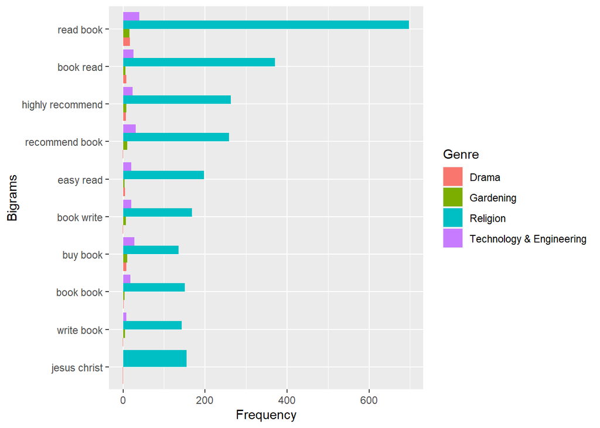

```r
# Extracting the top 10 bigrams
top_bigrams <- top_n(bigram_counts, 10, n)$bigram

# Grouping the cleaned bigrams by genre and counting occurrences
grouped_count <- group_by(clean_bigrams, Genre) %>%
  count(bigram) %>%
  filter(bigram %in% top_bigrams)

# Reordering bigrams for plotting
grouped_count$bigram <- factor(grouped_count$bigram, levels = top_bigrams[length(top_bigrams):1])

# Creating a grouped bar plot
ggplot(data = grouped_count, aes(x = bigram, y = n, fill = Genre)) +
  geom_col(position = "dodge") +
  labs(x = "Bigrams", y = "Frequency", fill = "Genre") +
  coord_flip()
```

### Creating Clean Word Cloud

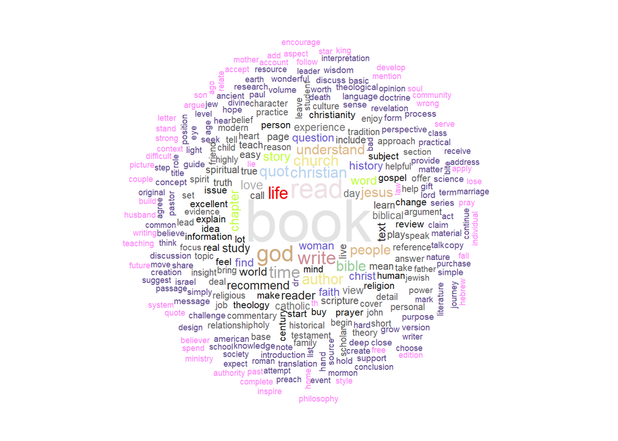

```r
set.seed(1)
wordcloud(words = word_counts$word, freq = word_counts$n, min.freq = 200, random.order=FALSE, random.color=FALSE, colors = sample(colors(), size = 100))
```

## Sentiment Analysis

### Bing Lexicons

```r
# Loads the bing sentiment lexicon
bing_sentiments <- get_sentiments("bing")

# Display summary statistics of the bing sentiment lexicon
summary(bing_sentiments)
```

```
##      word            sentiment
##  Length:6786        Length:6786
##  Class :character   Class :character
##  Mode  :character   Mode  :character
```

```r
# Print the unique sentiments available in the bing lexicon
print(unique(bing_sentiments$sentiment))
```

```
## [1] "negative" "positive"
```

```r
# Set seed for reproducibility
set.seed(2)

# Returns a sample of 5 random rows from the bing sentiment lexicon
sampled_bing_sentiments <- bing_sentiments[sample(nrow(bing_sentiments), 5),]
```

### AFINN Lexicon

```r
# Load the AFINN sentiment lexicon
afinn_sentiments <- get_sentiments("afinn")

# Display summary statistics of the AFINN sentiment lexicon
summary(afinn_sentiments)
```

```
##      word               value
##  Length:2477        Min.   :-5.0000
##  Class :character   1st Qu.:-2.0000
##  Mode  :character   Median :-2.0000
##                     Mean   :-0.5894
##                     3rd Qu.: 2.0000
##                     Max.   : 5.0000
```

```r
# Print the unique sentiment values available in the AFINN lexicon
print(sort(unique(afinn_sentiments$value)))
```

```
##  [1] -5 -4 -3 -2 -1  0  1  2  3  4  5
```

```r
# Set seed for reproducibility
set.seed(1)

# Sample 5 random rows from the AFINN sentiment lexicon
sampled_afinn_sentiments <- afinn_sentiments[sample(nrow(afinn_sentiments), 5),]
```

### NRC Lexicons

```r
# Load the NRC sentiment lexicon
nrc_sentiments <- get_sentiments("nrc")

# Display summary statistics of the NRC sentiment lexicon
summary(nrc_sentiments)
```

```
##      word            sentiment
##  Length:13872       Length:13872
##  Class :character   Class :character
##  Mode  :character   Mode  :character
```

```r
# Display the first few rows of the NRC sentiment lexicon
head(nrc_sentiments)
```

```
## # A tibble: 6 × 2
##   word      sentiment
##   <chr>     <chr>
## 1 abacus    trust
## 2 abandon   fear
## 3 abandon   negative
## 4 abandon   sadness
## 5 abandoned anger
## 6 abandoned fear
```

```r
# Print the unique sentiments available in the NRC lexicon
print(unique(nrc_sentiments$sentiment))
```

```
##  [1] "trust"        "fear"         "negative"     "sadness"      "anger"
##  [6] "surprise"     "positive"     "disgust"      "joy"          "anticipation"
```

```r
# Set seed for reproducibility
set.seed(1)

# Sample 5 random rows from the NRC sentiment lexicon
sampled_nrc_sentiments <- nrc_sentiments[sample(nrow(nrc_sentiments), 5),]
```

### Applying bing lexicon

```r
# Create dataset containing only words with associated sentiment & adds sentiment column.
sentiment_data <- clean_tokens %>%
  inner_join(get_sentiments("bing"), by = "word") # Joins lexicon to data set using only words that are in both.

# Calculate Sentiment scores for each review
sentiment_score <- sentiment_data %>%
  group_by(Review_no) %>%
  summarize(bing_sentiment = sum(sentiment == "positive") - sum(sentiment == "negative")) # Calculates sentiment score as sum of number of positive and negative sentiments

# Merge with df
df_with_sentiment = df %>%
  inner_join(sentiment_score, by = "Review_no")
```

### Worse Reviews using the bing lexicon

```r
# Extract the review with the lowest sentiment score
worst_reviews = df_with_sentiment[order(df_with_sentiment$bing_sentiment)[1],"Review_text"]

# Loop through each review and print it
for (review in worst_reviews){
  print(review)
}
```

```
## [1] "Christianity has been doing its best to \"defeat\" the divine feminine and sexually-empowered women since its inception. Any argument with that should begin with an education on the women's holocaust: the witch hunt hysteria. Witch hunts began with the publication of the book, Malleus Malefi…
```

### Best Reviews using the bing lexicon

```r
# Select the review with the highest sentiment score based on Bing lexicon
best_reviews = df_with_sentiment[order(df_with_sentiment$bing_sentiment, decreasing = TRUE)[1],"Review_text"]

# Iterate over each selected review and print it
for (review in best_reviews){
  print(review)
}
```

```
## [1] "While there are many good books that defend the doctrine of infant baptism from the perspective of covenant theology, there are very few that relate the doctrine of infant baptism to the position of baptized children in the church and their relation to the Lord. This particular question is a…
```

### Visualisations of bing lexicon

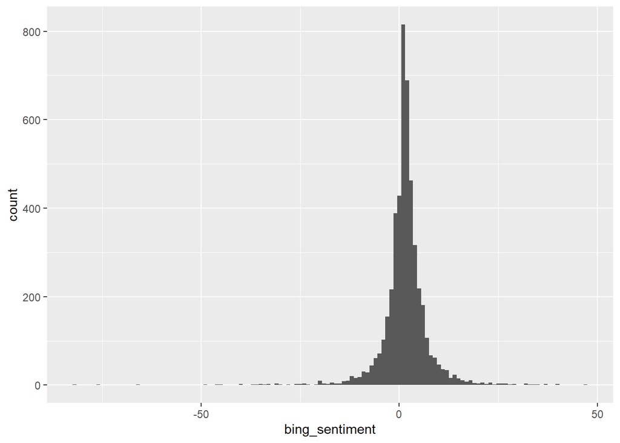

```r
# Histogram of sentiment scores
ggplot(df_with_sentiment, aes(x = bing_sentiment)) +
  geom_histogram(binwidth = 1)
```

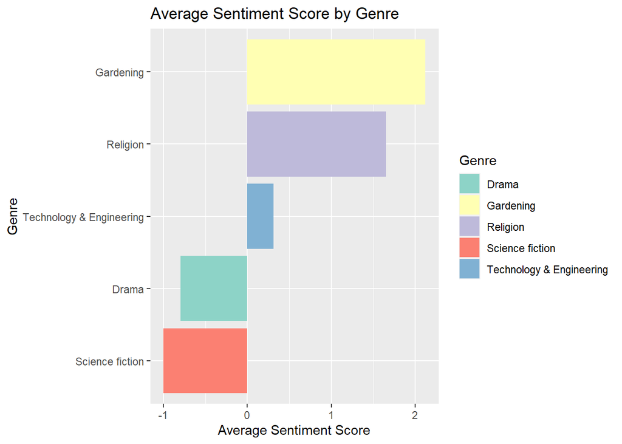

```r
# Average Sentiment by Genre
genre_sentiment <- df_with_sentiment %>%
  group_by(Genre) %>%
  summarize(Average_Bing_Sentiment = mean(bing_sentiment, na.rm = TRUE))  # Added na.rm = TRUE to handle potential NA values

# Create a color palette for genres
color_palette <- scales::brewer_pal(palette = "Set3")(length(unique(genre_sentiment$Genre)))

ggplot(genre_sentiment, aes(x = reorder(Genre, Average_Bing_Sentiment), y = Average_Bing_Sentiment, fill = Genre)) +
  geom_bar(stat = "identity") +
  scale_fill_manual(values = color_palette) +  # Set custom colors
  coord_flip() +
  labs(title = "Average Sentiment Score by Genre", x = "Genre", y = "Average Sentiment Score")
```

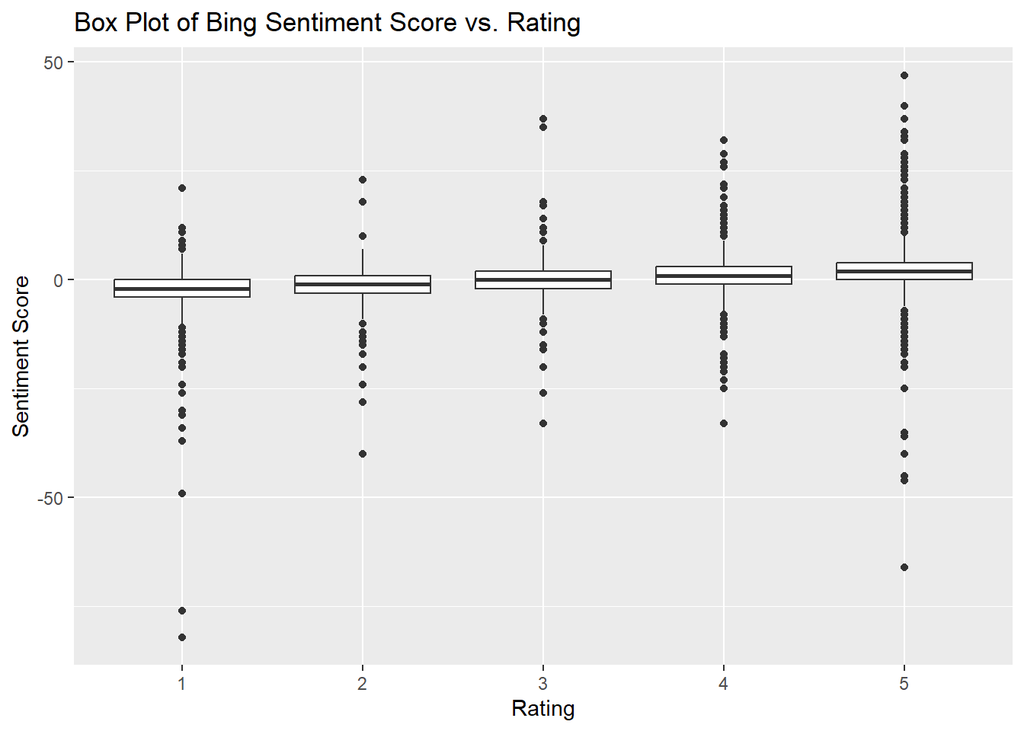

```r
# Box Plot of Sentiment against rating
ggplot(df_with_sentiment, aes(x = as.factor(Rating), y = bing_sentiment)) +  # Converted Rating to factor for better representation
  geom_boxplot() +
  labs(title = "Box Plot of Bing Sentiment Score vs. Rating",
       x = "Rating",
       y = "Sentiment Score")
```

# Applying AFINN lexicon

```r
# Create dataset containing only words with associated sentiment & adds sentiment column.
sentiment_data <- clean_tokens %>%
  inner_join(get_sentiments("afinn"), by = "word")

# Calculate Sentiment scores for each review
sentiment_score <- sentiment_data %>%
  group_by(Review_no) %>%
  summarize(afinn_sentiment = sum(value))

# Merge with df
df_with_sentiment = df_with_sentiment %>%
  inner_join(sentiment_score, by = "Review_no")
```

### Worse Reviews from the AFINN lexicon

```r
worst_reviews = df_with_sentiment[order(df_with_sentiment$afinn_sentiment)[1],"Review_text"]


for (review in worst_reviews){
  print(review)
}
```

```
## [1] "Christianity has been doing its best to \"defeat\" the divine feminine and sexually-empowered women since its inception. Any argument with that should begin with an education on the women's holocaust: the witch hunt hysteria. Witch hunts began with the publication of the book, Malleus Malefi…
```

### Best Reviews from the AFINN lexicon

```r
### Best Review
best_reviews = df_with_sentiment[order(df_with_sentiment$afinn_sentiment, decreasing = TRUE)[1],"Review_text"]

for (review in best_reviews){
  print(review)
}
```

```
## [1] "[again, as no doubt will always be the case, i have to change what i have written!/eat my words]dionysius is close to the neoplatonists, though predates plotinus by two or three centuries. he believes that god is not only that from which everything proceedes and in and by which all exist/hav…
```

### Visualisations of afinn lexicon

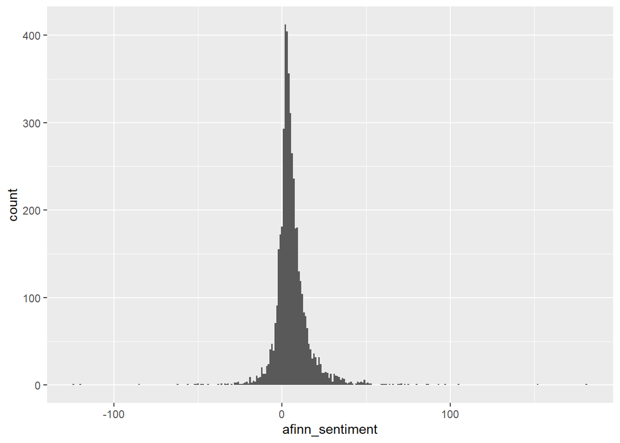

```r
# Histogram of sentiment scores
ggplot(df_with_sentiment, aes(x = afinn_sentiment)) +
  geom_histogram(binwidth = 1)
```

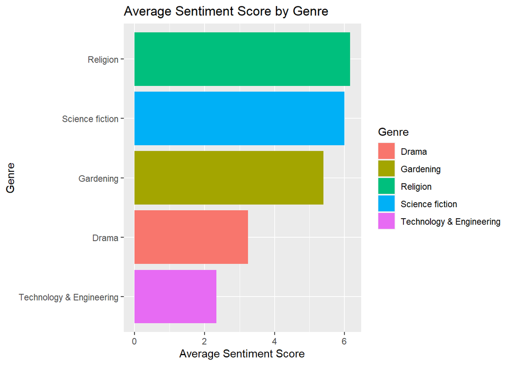

```r
# Average Sentiment by Genre
genre_sentiment <- df_with_sentiment %>%
  group_by(Genre) %>%
  summarize(Average_Afinn_Sentiment = mean(afinn_sentiment, na.rm = TRUE))  # Added na.rm = TRUE to handle potential NA values

ggplot(genre_sentiment, aes(x = reorder(Genre, Average_Afinn_Sentiment), y = Average_Afinn_Sentiment, fill = Genre)) +
  geom_bar(stat = "identity") +
  coord_flip() +
  labs(title = "Average Sentiment Score by Genre", x = "Genre", y = "Average Sentiment Score")
```

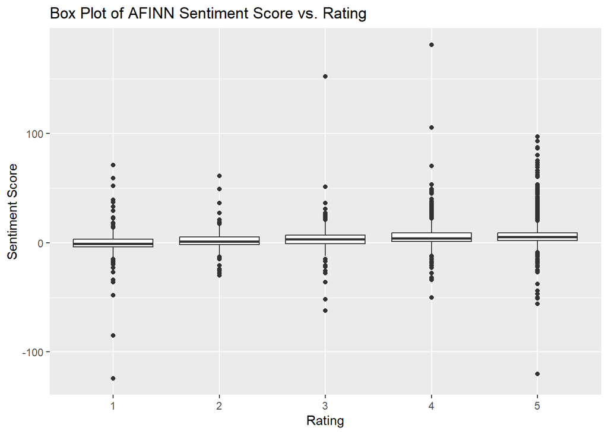

```r
# Box Plot of Sentiment against rating
ggplot(df_with_sentiment, aes(x = as.factor(Rating), y = afinn_sentiment)) +  # Converted Rating to factor for better representation
  geom_boxplot() +
  labs(title = "Box Plot of AFINN Sentiment Score vs. Rating",
       x = "Rating",
       y = "Sentiment Score")
```

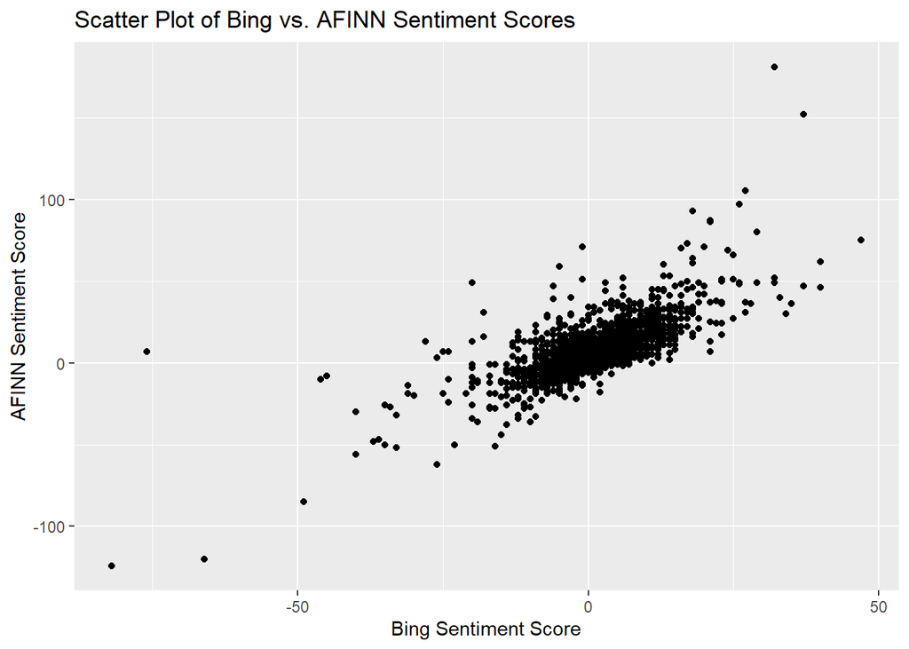

```r
# Scatter Plot of Bing vs. AFINN Sentiment
ggplot(df_with_sentiment, aes(x = bing_sentiment, y = afinn_sentiment)) +
  geom_point() +
  labs(title = "Scatter Plot of Bing vs. AFINN Sentiment Scores",
       x = "Bing Sentiment Score",
       y = "AFINN Sentiment Score")
```

### Applying NRC lexicon

```r
# Create dataset containing only words with associated sentiment & adds sentiment column.
emotion_data <- clean_tokens %>%
  inner_join(get_sentiments("nrc"), by = c("word" = "word"), suffix = c("", "_sentiment"))
# Calculate Sentiment scores for each review
emotion_count <- emotion_data %>%
  group_by(Review_no) %>%
  count(sentiment)

# Pivots data so that there is a column associated with each emotion
wide_emotion_data <- emotion_count %>%
  pivot_wider(names_from = sentiment, values_from = n, values_fill = list(n = 0))

# Merge with df
df_with_sentiment = df_with_sentiment %>%
  inner_join(wide_emotion_data, by = "Review_no")
```

### Visualisations of NRC lexicon

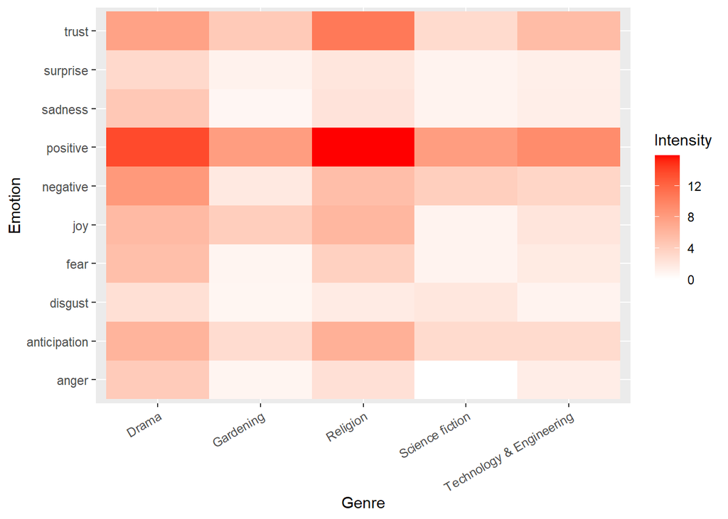

```r
long_df <- df_with_sentiment %>%
  pivot_longer(cols = c("joy", "positive", "trust", "anticipation", "surprise", "sadness", "negative", "anger", "disgust", "fear"),
               names_to = "Emotion",
               values_to = "Intensity")

emotion_scores <- long_df %>%
  group_by(Genre, Emotion) %>%
  summarize(avg_intensity = mean(Intensity), .groups = 'drop')

ggplot(emotion_scores, aes(x = Genre, y = Emotion, fill = avg_intensity)) +
  geom_tile() +  # Creates the heatmap tiles
  scale_fill_gradient2(low = "blue", high = "red") +  # Adjust colors
  labs(x = "Genre", y = "Emotion", fill = "Intensity") +
  theme(axis.text.x = element_text(angle = 30, hjust=1))  # Rotates text to 30 degrees and hjust=1 aligns text to the right
```

**Observation**

# Task C – Topic Modelling

## Data Selection and Sampling for Topic Modeling

```r
## Load the Data into data frame
df <- read.csv(file_path, stringsAsFactors = FALSE, na.strings = c("", "NA"))

# Select and filter data
df <- df %>%
  select(Title, Review_text, Genre,Rating, First_author, Publisher) %>%
  filter(str_count(Review_text) >= 20 & str_count(Review_text) <= 1000)

# Remove rows containing null values
df <- na.omit(df)

if(nrow(df) > 6000) {
  set.seed(1) # for reproducibility
  df <- sample_n(df, 6000)
}
```

### Convert Data to a Clean Term Document Matrix (TDM)

```r
# Convert text column to corpus
corpus <- VCorpus(VectorSource(df$Review_text))

# Apply cleaning
corpus <- corpus %>%
  tm_map(content_transformer(tolower)) %>%
  tm_map(content_transformer(function(x) gsub("[^a-zA-Z ]", "", x))) %>%
  tm_map(removeWords, stopwords("en")) %>%
  tm_map(stemDocument)

# Convert to a term document matrix
# Word length between 3 and 15 words
tdm <- TermDocumentMatrix(corpus, control = list(wordLengths = c(3, 15)))

tdm_matrix <- as.matrix(tdm)
```

### Further Selection of Words

```r
term_frequencies <- rowSums(tdm_matrix)

# Create a data frame for plotting
term_frequency_df <- data.frame(term = names(term_frequencies), frequency = term_frequencies)

# Sort the data frame by frequency in descending order and select the top 10
top_terms <- term_frequency_df %>%
  arrange(desc(frequency)) %>%
  head(10)

# Display the top 10 terms
print(top_terms)
```

```
##        term frequency
## book   book      9688
## read   read      3792
## one     one      1860
## like   like      1455
## great great      1424
## stori stori      1300
## good   good      1242
## love   love      1146
## time   time      1130
## use     use      1127
```

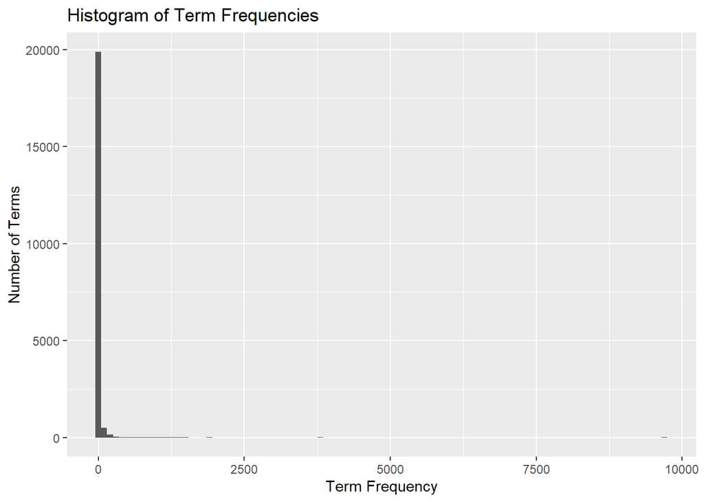

```r
# Create the histogram
ggplot(term_frequency_df, aes(x = frequency)) +
  geom_histogram(binwidth = 100) +
  labs(title = "Histogram of Term Frequencies",
       x = "Term Frequency",
       y = "Number of Terms")
```

```r
# Find terms that appear in more than 10% of documents
frequent_terms <- findFreqTerms(tdm, lowfreq = 0.1 * ncol(tdm_matrix))
# Find terms that appear in less than 1% of documents
rare_terms <- findFreqTerms(tdm, highfreq = 0.01 * ncol(tdm_matrix))

print("Frequent Terms")
```

```
## [1] "Frequent Terms"
```

```r
print(frequent_terms)
```

```
##  [1] "also"       "author"     "book"       "can"        "charact"
##  [6] "enjoy"      "even"       "find"       "first"      "found"
## [11] "get"        "give"       "good"       "great"      "help"
## [16] "inform"     "interest"   "just"       "know"       "life"
## [21] "like"       "look"       "love"       "make"       "mani"
## [26] "much"       "one"        "peopl"      "read"       "realli"
## [31] "recommend"  "stori"      "think"      "time"       "understand"
## [36] "use"        "want"       "way"        "well"       "work"
## [41] "write"      "written"    "year"
```

```r
print("First 20 Infrequent Terms")
```

```
## [1] "First 20 Infrequent Terms"
```

```r
print(rare_terms[1:20])
```

```
##  [1] "aaaa"       "aaliyah"    "aasimov"    "aau"        "abandon"
##  [6] "abash"      "abaut"      "abbey"      "abbi"       "abbott"
## [11] "abbrevi"    "abc"        "abdomin"    "abdul"      "abe"
## [16] "abelard"    "aberr"      "abid"       "abigail"    "abilitiesi"
```

```r
# Edit list of frequent words to keep useful ones
to_keep <- c("famili", "love", "murder","recommend","charact","love")

to_remove <- frequent_terms[!frequent_terms %in% to_keep]

filtered_tdm_matrix <- tdm_matrix[!rownames(tdm_matrix) %in% to_remove, ]
filtered_tdm_matrix <- filtered_tdm_matrix[!rownames(filtered_tdm_matrix) %in% rare_terms, ]

# Calculate column sums
column_sums <- colSums(filtered_tdm_matrix)

# Identify columns that are all zeros
zero_columns <- which(column_sums == 0)

# Remove these columns
if(length(zero_columns) > 0) {
  # Remove these columns
  filtered_tdm_matrix <- filtered_tdm_matrix[, -zero_columns]
} else {
  # If no columns are all zeros, just use the original matrix
  print("No zero columns in TDM matrix")
}
```

```r
term_frequencies <- rowSums(filtered_tdm_matrix)

# Create a data frame for plotting
term_frequency_df <- data.frame(term = names(term_frequencies), frequency = term_frequencies)

# Sort the data frame by frequency in descending order and select the top 10
top_terms <- term_frequency_df %>%
  arrange(desc(frequency)) %>%
  head(10)

# Display the top 10 terms
print(top_terms)
```

```
##                term frequency
## love           love      1146
## recommend recommend       880
## charact     charact       662
## new             new       586
## need           need       556
## learn         learn       541
## thing         thing       541
## high           high       535
## dont           dont       526
## best           best       509
```

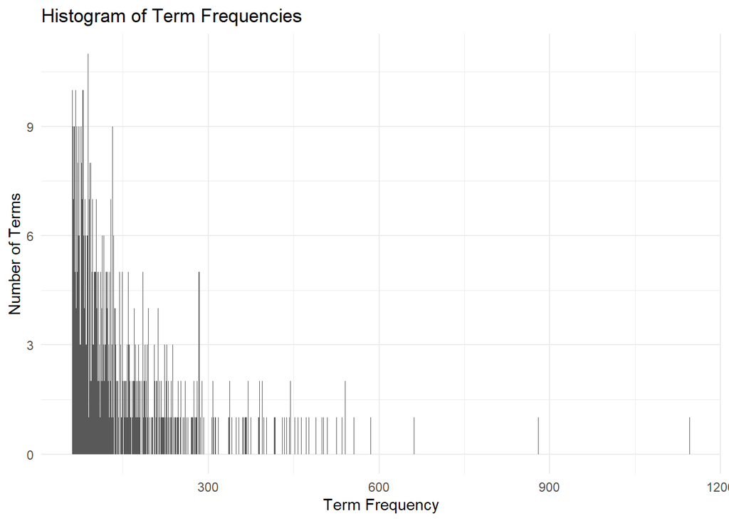

```r
# Create the histogram
ggplot(term_frequency_df, aes(x = frequency)) +
  geom_histogram(binwidth = 1) +
  labs(title = "Histogram of Term Frequencies",
       x = "Term Frequency",
       y = "Number of Terms") +
  theme_minimal()
```

```r
to_remove <- c("seem","much","give", "author","time","book","one","read","good","will","put","alway")

filtered_tdm_matrix <- filtered_tdm_matrix[!rownames(filtered_tdm_matrix) %in% to_remove, ]

term_frequencies <- rowSums(filtered_tdm_matrix)

# Create a data frame for plotting
term_frequency_df <- data.frame(term = names(term_frequencies), frequency = term_frequencies)

# Sort the data frame by frequency in descending order and select the top 10
top_terms <- term_frequency_df %>%
  arrange(desc(frequency)) %>%
  head(10)

# Display the top 10 terms
print(top_terms)
```

```
##                term frequency
## love           love      1146
## recommend recommend       880
## charact     charact       662
## new             new       586
## need           need       556
## learn         learn       541
## thing         thing       541
## high           high       535
## dont           dont       526
## best           best       509
```

### Apply LDA

```r
dtm <- t(filtered_tdm_matrix)
lda_model <- LDA(dtm, k = 5)
```

## Topic Modelling Visualisation

```r
# Extract the terms associated with each topic from the LDA model
topics <- tidy(lda_model, matrix = "beta")

# Display the top terms for each topic
topics
```

```
## # A tibble: 3,165 × 3
##    topic term      beta
##    <int> <chr>    <dbl>
##  1     1 abil  0.000551
##  2     2 abil  0.000431
##  3     3 abil  0.00106
##  4     4 abil  0.000184
##  5     5 abil  0.00109
##  6     1 abl   0.00207
##  7     2 abl   0.00102
##  8     3 abl   0.00303
##  9     4 abl   0.000889
## 10     5 abl   0.00248
## # ℹ 3,155 more rows
```

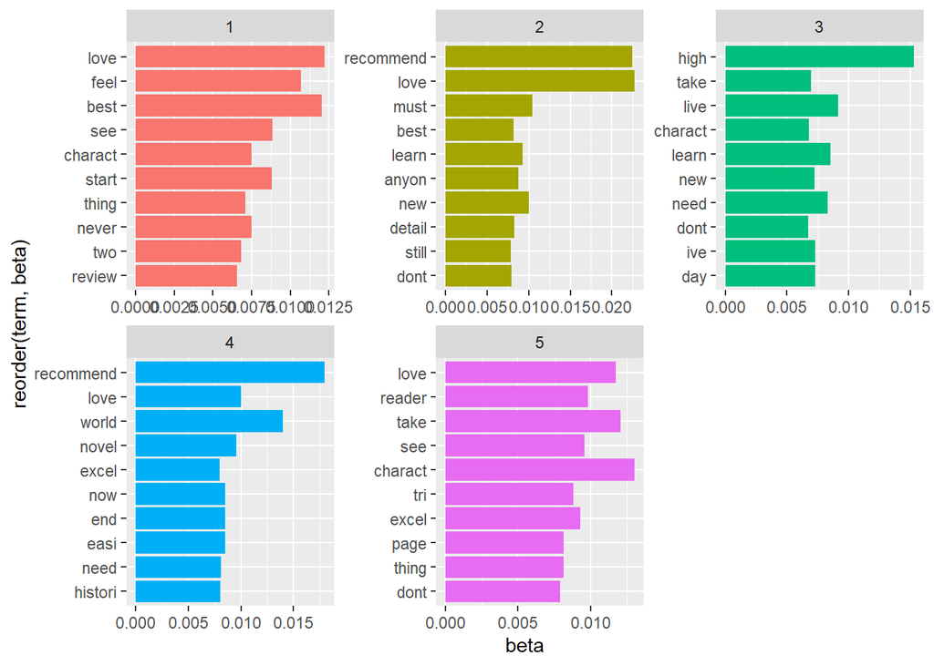

```r
# Group terms by topic and select the top 10 terms based on beta values
top_terms <- topics %>%
  group_by(topic) %>%
  top_n(10, beta) %>%
  ungroup() %>%
  arrange(topic, -beta)

# Plot the top terms for each topic using ggplot
top_terms %>%
  ggplot(aes(x = reorder(term, beta), y = beta, fill = factor(topic))) +
  geom_col(show.legend = FALSE) +
  facet_wrap(~ topic, scales = "free") +
  coord_flip()
```

### Deciding K

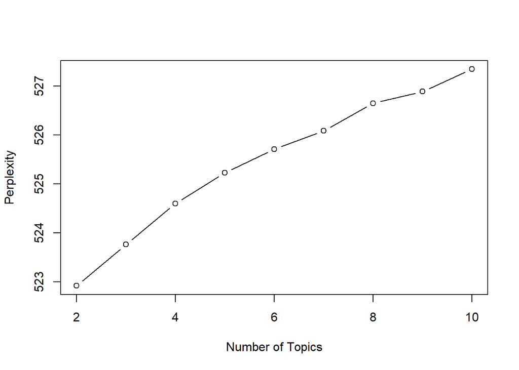

```r
range_k <- seq(2, 10, by = 1)  # Adjust the range as needed
perplexities <- sapply(range_k, function(k) {
  model <- LDA(dtm, k = k, control = list(seed = 1))
  perplexity(model)
})

# Plotting perplexities
plot(range_k, perplexities, type = "b", xlab = "Number of Topics", ylab = "Perplexity")
```

## Interactive Principal Componenet Space Visualisation

```r
# Set seed for reproducibility
set.seed(1)

# Create the LDA model with 5 topics
lda_model <- LDA(dtm, k = 5)

# Prepare data for visualization
lda_vis_data <- createJSON(phi = posterior(lda_model)$terms,
                            theta = posterior(lda_model)$topics,
                            doc.length = rowSums(as.matrix(dtm)),
                            vocab = colnames(as.matrix(dtm)),
                            term.frequency = colSums(as.matrix(dtm)))

# Visualize the LDA model using SerVis
serVis(lda_vis_data)
```

## Topic Modelling Visualisation

```r
# Extract topic-term distributions from the LDA model
topics <- tidy(lda_model, matrix = "beta")

# Display the topic-term distributions
topics
```

```
## # A tibble: 3,165 × 3
##    topic term      beta
##    <int> <chr>    <dbl>
##  1     1 abil  0.000438
##  2     2 abil  0.000378
##  3     3 abil  0.000635
##  4     4 abil  0.000892
##  5     5 abil  0.000974
##  6     1 abl   0.00190
##  7     2 abl   0.00127
##  8     3 abl   0.00229
##  9     4 abl   0.00106
## 10     5 abl   0.00297
## # ℹ 3,155 more rows
```

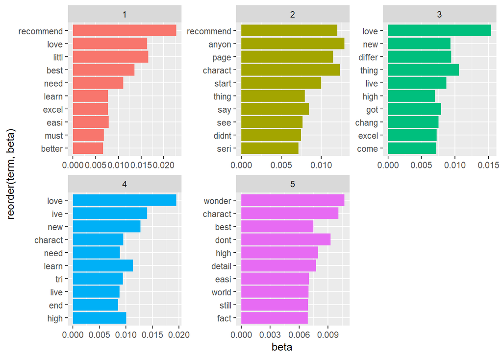

```r
# Select the top 10 terms for each topic based on beta values
top_terms <- topics %>%
  group_by(topic) %>%
  top_n(10, beta) %>%
  ungroup() %>%
  arrange(topic, -beta)

# Plot the top terms for each topic
top_terms %>%
  ggplot(aes(x =reorder(term, beta), y = beta, fill = factor(topic))) +
  geom_col(show.legend = FALSE) +
  facet_wrap(~ topic, scales = "free") +
  coord_flip()
```

# Task D – Further exploration

## Network Analysis

According to Borgatti et al. (2018), Network analysis in R involves studying the structure, relationships, and properties of networks or graphs using various analytical and visual techniques . Key tasks include loading and manipulating networks, descriptive analysis, visualization, centrality measures, community detection, network modelling, and analysis of dynamic networks.

```r
## Load the Data into data frame
df <- read.csv(file_path, stringsAsFactors = FALSE, na.strings = c(" ", "NA"))

set.seed(123)

# Create an empty adjacency matrix
adj_matrix <- matrix(0, ncol = ncol(df), nrow = ncol(df))

# Define the condition for establishing connections
for (i in 1:(ncol(df) - 1)) {
  for (j in (i + 1):ncol(df)) {
    # Check if the two columns share common reviewers
    if (length(intersect(df[, i], df[, j])) > 0) {
      adj_matrix[i, j] <- 1
      adj_matrix[j, i] <- 1  # Assuming undirected network
    }
  }
}


# Create a graph object
g <- graph_from_adjacency_matrix(adj_matrix, weighted = TRUE, mode = "undirected")

# Set node names
V(g)$name <- colnames(df)
```

### Applying Network Analysis

In this section, we perform basic network analysis on the prepared network. we calculate the degree centrality, which measures the number of connections each node has. Eigenvector centrality measures the influence of a node in the network based on the connections it has to other influential nodes.Betweenness centrality measures the extent to which a node lies on the shortest paths between other nodes in the network This metric provides insights into the importance of individual nodes within the network.

According to ChatGPT (2024), this code retrieved and adapted to provides valuable insights into network structures.

```r
# Additional network metrics()
betweenness <- betweenness(g)
mean_betweenness <- mean(betweenness)
cat("Mean Betweenness Centrality:", mean_betweenness, "\n")
```

```
## Mean Betweenness Centrality: 1.818182
```

```r
# Closeness centrality
closeness <- closeness(g)
mean_closeness <- mean(closeness)
cat("Mean Closeness Centrality:", mean_closeness, "\n")
```

```
## Mean Closeness Centrality: NaN
```

```r
# Eigenvector centrality
eigen <- eigen_centrality(g)$vector
mean_eigen <- mean(eigen)
cat("Mean Eigenvector Centrality:", mean_eigen, "\n")
```

```
## Mean Eigenvector Centrality: 0.4675542
```

**Observation**

1. **Mean Betweenness Centrality:** The value of `1.818182` suggests that, on average, the nodes in the network lie on approximately `1.82` shortest paths between other nodes. This means that, on average, each node serves as a bridge or intermediary for communication between other nodes approximately `1.82` times. Nodes with higher betweenness centrality are more critical for maintaining connectivity and facilitating communication between different parts of the network.
2. **Mean Closeness Centrality:** The value of `NaN` indicates that the mean closeness centrality could not be calculated. This could be due to disconnected nodes in the network or nodes that cannot reach other nodes. In a network where the mean closeness centrality can be calculated, higher values would indicate that, on average, nodes are closer to all other nodes in the network, enabling efficient information flow and communication.
3. **Mean Eigenvector Centrality:** The value of `0.4675542` suggests that, on average, the nodes in your network have a moderate to high influence relative to other nodes. This means that, on average, nodes are connected to other nodes with moderate to high influence or importance. Nodes with higher eigenvector centrality are more influential and have a greater impact on the overall network structure and dynamics.

These explanations provide insights into the specific roles and importance of nodes in the network based on their betweenness, closeness, and eigenvector centrality values.

### Visualize Network

In this section, we visualize the network using a graph plot. We apply the Fruchterman-Reingold layout algorithm to arrange the nodes in a visually appealing manner. Additionally, we adjust the edge properties such as arrow size and curvature for better clarity.

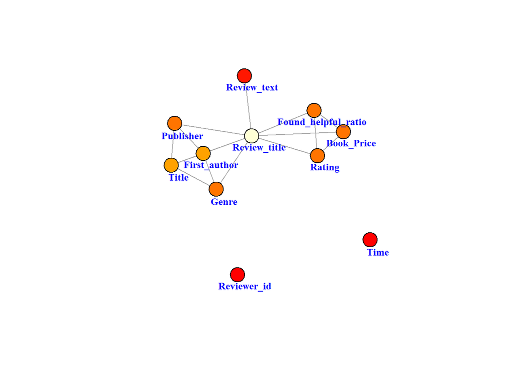

```r
# Customized plot with node colouring based on centrality and node names
plot(g,
     layout = layout_with_fr(g),
     vertex.label = V(g)$name,  # Display node names
     vertex.color = heat.colors(15)[cut(degree(g), breaks = 15)], # Colour nodes based on degree centrality
     vertex.size = 15,  # Set the size of the nodes
     vertex.frame.color = "black",  # Color of the node border
     vertex.shape = "circle",  # Shape of the nodes
     vertex.label.font = 2,  # Bold font for node labels
     vertex.label.cex = 0.8,  # Adjust label size
     vertex.label.color = "blue",  # Color of the node labels
     vertex.label.dist = 2,  # Distance of the labels from nodes
     vertex.label.degree = 1,  # Orientation of the labels (0 for horizontal)
     edge.arrow.size = 5,
     edge.curved = FALSE)
```

**Observation**

> 1. **Nodes that are connected:**
> - These nodes represent entities with shared relationships or connections.
> - The edges between connected nodes illustrate these relationships.
> 2. **Nodes that are not connected:**
> - These nodes represent isolated entities without direct connections.
> - They may have unique attributes or belong to distinct categories.

### Disscussion of Future Work

In addition to sentiment analysis and topic modelling, there are several other advanced models and techniques that can be explored for text analysis and natural language processing (NLP). Some of these include:

**Text Classification:** Text categorization is the process of grouping text materials into groupings or categories that have been predetermined (Sebastiani, 2002). Tasks like spam detection, document categorization, sentiment classification (beyond just positive/negative sentiment), and more can benefit from this. For better classification performance, sophisticated methods such as deep learning-based models (such as Convolutional and Recurrent neural networks) might be used (Kim, 2014).

**Named Entity Linking (NEL):** Named Entity Linking is the task of linking named entities mentioned in text to their corresponding entries in a knowledge base or database (Ferragina & Scaiella, 2012). With the use of NEL, textual data may be enhanced with more context and semantics and entity distinction.

**Text Summarization:** The goal of text summarising techniques is to provide logical and succinct summaries of larger text documents automatically. This can be accomplished through the use of abstractive techniques, which create new sentences that encapsulate the main ideas of the original text, or extractive techniques, which involve picking and rearranging significant sentences or phrases from the original text (Nenkova & McKeown, 2011).

## References

Ferragina, P., & Scaiella, U. (2012). Fast and accurate annotation of short texts with Wikipedia pages. *IEEE Software*, 29(1), 70–75. doi: 10.1109/ms.2011.122

Jurafsky, D., & Martin, J. H. (2020). Speech and Language Processing: An Introduction to Natural Language Processing, Computational Linguistics, and Speech Recognition (3rd ed.). Available at: https://web.stanford.edu/~jurafsky/slp3/ed3book.pdf

Kim, Y. (2014). Convolutional neural networks for sentence classification. *ArXiv (Cornell University)*, pp. 1746–1751. Available at: https://aclanthology.org/D14-1181/

Nenkova, A., & McKeown, K. (2011). Automatic summarization. *Foundations and Trends® in Information Retrieval*, 5(2-3), 103–233. doi: 10.1561/1500000015

Sebastiani, F. (2002). Machine learning in automated text categorization. *ACM Computing Surveys*, 34(1), 1–47. Available at: https://dl.acm.org/citation.cfm?id=505283

Borgatti, S. P., Everett, M. G., & Johnson, J. C. (2018). Analyzing social networks. Sage publications.